# Analysis of Alpha and Beta diversity in R - rarefaction, alpha- and beta- diversity and vizualizations Deehan_2020_V5V6_forward_only-tapioca

### Packages needed:

```r
require(vegan)
```

```r
require(ggplot2)
require(data.table)
require(anchors)
require(EcolUtils)
require(car)
require(tidyverse)
require(dplyr)
require(rstatix)
library("extrafont")
```

### Set working directory:

```r
setwd("/Volumes/Seagate/Meta_analysis/Alpha_Beta_analysis/Deehan_2020_V5V6/tapioca/")
```

## __________ Documents needed: __________

- 1. *SV.table* - **filtered_forward_phylum_feature-table_modified_header.tsv** is the operational taxonomic unit table (OTU table) that was obtained after DADA2 and underwent curation by clearing mitochondrial and chloroplast DNA and only keeping OTUs that were assigned to the phylum level named. The header was modified to remove “Constructed from biom file” line and changed “OTU ID” to OTUID"
- 2. *Metadata* - **Deehan_metadata_tapioca.txt** is the Metadata file containing the description of each sample.

*The files chosen are from the processing of the forward end reads.

## __________ Read in your data _________

#### Import metadata:

```r
setwd("/Volumes/Seagate/Meta_analysis/Alpha_Beta_analysis/Deehan_2020_V5V6/Input_files")

metadata <- as.data.frame(fread("1.Deehan_metadata_tapioca.tsv"))

str(metadata)
```

```
#> 'data.frame':    50 obs. of  19 variables:
#>  $ sampleid            : chr  "deehan_SRR10022115" "deehan_SRR10022160" "deehan_SRR10022167" "deehan_SRR10022168" ...
#>  $ study               : chr  "deehan" "deehan" "deehan" "deehan" ...
#>  $ sample_id_2         : chr  "SRR10022115" "SRR10022160" "SRR10022167" "SRR10022168" ...
#>  $ subject_id          : chr  "deehan_M41" "deehan_F09" "deehan_F02" "deehan_F12" ...
#>  $ treatment           : chr  "fiber" "fiber" "fiber" "fiber" ...
#>  $ timepoint           : chr  "before" "before" "before" "before" ...
#>  $ timepoint_numeric   : int  1 1 1 1 1 1 1 1 1 1 ...
#>  $ timepoint_id        : chr  "before_1" "before_1" "before_1" "before_1" ...
#>  $ sample_name         : chr  "deehan_M41_1" "deehan_F09_1" "deehan_F02_1" "deehan_F12_1" ...
#>  $ fiber_type          : chr  "tapioca" "tapioca" "tapioca" "tapioca" ...
#>  $ fiber_amount        : chr  "0g" "0g" "0g" "0g" ...
#>  $ time_days           : chr  "0d" "0d" "0d" "0d" ...
#>  $ number              : int  24 69 76 77 79 82 117 128 154 193 ...
#>  $ gender              : logi  NA NA NA NA NA NA ...
#>  $ age                 : logi  NA NA NA NA NA NA ...
#>  $ sample-name-original: chr  "M41W0" "F09W0" "F02W0" "F12W0" ...
#>  $ subject_id2         : chr  "M41" "F09" "F02" "F12" ...
#>  $ sampleid2           : chr  "SRR10022115" "SRR10022160" "SRR10022167" "SRR10022168" ...
#>  $ fiber_amount2       : chr  "<10g" "<10g" "<10g" "<10g" ...
```

##### In metadata file, set subject-id, timepoint as factors: There are a number of advantages to converting categorical variables to factor variables. For instance, they can be used in statistical modeling where they will be implemented correctly, i.e., they will then be assigned the correct number of degrees of freedom

```r
metadata <- metadata %>%
  convert_as_factor(`timepoint`)

metadata <- metadata %>%
  convert_as_factor(`subject_id`)

metadata <- metadata %>%
  convert_as_factor(`subject_id2`)

metadata <- metadata %>%
  convert_as_factor(`sampleid`)

metadata <- metadata %>%
  convert_as_factor(`sampleid2`)

metadata <- metadata %>%
  convert_as_factor(`fiber_amount2`)

#Confirm variables have been changed to factors:
class(metadata$`timepoint`)
```

```
#> [1] "factor"
```

```r
class(metadata$`subject_id`)
```

```
#> [1] "factor"
```

```r
class(metadata$`subject_id2`)
```

```
#> [1] "factor"
```

```r
class(metadata$`sampleid`)
```

```
#> [1] "factor"
```

```r
class(metadata$`sampleid2`)
```

```
#> [1] "factor"
```

```r
class(metadata$`fiber_amount2`)
```

```
#> [1] "factor"
```

#### Read in SV table with all data:

```r
setwd("/Volumes/Seagate/Meta_analysis/Alpha_Beta_analysis/Deehan_2020_V5V6/Input_files")

SV.table <- as.data.frame(fread("1.filtered_forward_phylum_feature-table_modified_header.tsv", header = TRUE))

#Set OTUID as the row names:
row.names(SV.table) <- SV.table$`#OTUID`
SV.table <- SV.table[ , !(names(SV.table) %in% c("#OTUID"))]
```

#### Subset samples in tapioca treatment only based on metadata:

```r
#Subset the samples in the inulin fiber intervention only:
SV.table_tapioca <- SV.table %>% select(metadata$sampleid2)
```

#### Save the subsetted data:

```r
setwd("/Volumes/Seagate/Meta_analysis/Alpha_Beta_analysis/Deehan_2020_V5V6/tapioca/Output_files")

#Save subset of samples in a file:
write.table(SV.table_tapioca, file = "1.SV.table_tapioca.tsv", sep = "\t", row.names = TRUE, col.names = NA)
```

## __________ Rarefy your data _________

#### Transform the dataframes because vegan expects rows = samples and columns = species:

```r
SV.table_tapioca <- as.data.frame(t(SV.table_tapioca))
```

#### Look at the first few rows and columns to ensure data got transposed:

```r
SV.table_tapioca[1:5,1:5]
```

```
#>             6e89346ff950a1d2f371436d4ac9ebe8 907f9c8c145f9671b631ff30ee869c7a
#> SRR10022115                                0                                0
#> SRR10022160                              246                                0
#> SRR10022167                                0                                0
#> SRR10022168                                0                                0
#> SRR10022170                              709                                0
#>             05bdb98f72177357703de452f3f44623 6c5d5ea7b5f2d14a0cb80f3163149843
#> SRR10022115                                0                                0
#> SRR10022160                                0                                0
#> SRR10022167                                0                                0
#> SRR10022168                                0                                0
#> SRR10022170                                0                                0
#>             2211a9a09318f83d497663087fd0b618
#> SRR10022115                                0
#> SRR10022160                               77
#> SRR10022167                              166
#> SRR10022168                               97
#> SRR10022170                              885
```

##### Delete the SVs that are not present at all in the samples, this can be possible as we subsetted the data and some SVs can be present in the other fiber treatments and not in this one for the same study:

```r
SV.table_tapioca <- SV.table_tapioca[, which(colSums(SV.table_tapioca) != 0)]
```

#### See the total number of samples and SVs, by looking at the dimensions of the table:

```r
dim(SV.table_tapioca)
```

```
#> [1]   50 1847
```

##### Results:

R always uses rows, then columns. So in this case we have and 50 samples and 1847 SVs.

#### If we now want to know the total number of reads we have we can just count up the total of the SVs sum in table:

```r
sum(SV.table_tapioca)
```

```
#> [1] 2342072
```

##### Results:

We have 2342072 reads.

#### To see the number of reads per sample, we simply need to add up the rows on the file:

```r
reads.per.sample <- rowSums(SV.table_tapioca) %>% sort()
reads.per.sample
```

```
#> SRR10022119 SRR10022115 SRR10022188 SRR10022118 SRR10022117 SRR10022145
#>        7157       25901       29791       30681       31379       32288
#> SRR10022236 SRR10022170 SRR10022172 SRR10022167 SRR10022242 SRR10022116
#>       33858       35324       36508       39122       39734       40191
#> SRR10022241 SRR10022174 SRR10022173 SRR10022220 SRR10022177 SRR10022243
#>       41576       42210       42223       43435       43509       43612
#> SRR10022149 SRR10022171 SRR10022150 SRR10022144 SRR10022133 SRR10022160
#>       44109       44898       45414       45562       47214       47220
#> SRR10022221 SRR10022148 SRR10022223 SRR10022146 SRR10022135 SRR10022245
#>       47479       47952       48205       48232       48840       49481
#> SRR10022244 SRR10022168 SRR10022219 SRR10022169 SRR10022142 SRR10022212
#>       49830       49956       50402       52621       53850       53987
#> SRR10022211 SRR10022147 SRR10022210 SRR10022161 SRR10022222 SRR10022143
#>       54325       55631       55844       56448       56926       57353
#> SRR10022208 SRR10022134 SRR10022285 SRR10022284 SRR10022287 SRR10022288
#>       57596       57737       58342       58975       60507       63328
#> SRR10022209 SRR10022286
#>       66024       69285
```

```r
#Save a file with the information of reads per sample:
setwd("/Volumes/Seagate/Meta_analysis/Alpha_Beta_analysis/Deehan_2020_V5V6/tapioca/Output_files")
write.table(reads.per.sample, file = "2.reads.per.sample.tsv", sep = "\t", row.names = TRUE, col.names = NA)
```

#### To see the max. & min. number of reads and how frequently certain features (SVs) are found, add up the rows and col:

```r
rowSums(SV.table_tapioca) %>% summary()
```

```
#>    Min. 1st Qu.  Median    Mean 3rd Qu.    Max.
#>    7157   41734   47716   46841   55304   69285
```

```r
colSums(SV.table_tapioca) %>% summary()
```

```
#>    Min. 1st Qu.  Median    Mean 3rd Qu.    Max.
#>     2.0    15.0    83.0  1268.0   454.5 67221.0
```

#### Result:

- The min. number of sequences in a sample is 7157 and the max. is 69285; we can use 7157 for rarefaction depth
- The min. value for the presence of an SV is 2 and the max. times an SV is present is 67221.

#### Performing the actual rarefaction

- Rarefaction depth should be >= 1000 at least, we will use the minimum value of sequence depth which is 7157
- Round out the averages, so we will not have exactly 7157 sequences in each, but we also will not be keeping the super rare, super low abundance << 1 taxa https://rdrr.io/github/GuillemSalazar/EcolUtils/man/rrarefy.perm.html

```r
set.seed(2022) #reproducible results
SV.table.rarefied <- as.data.frame((rrarefy.perm(SV.table_tapioca, sample = 7157, n = 1000, round.out = TRUE)))
```

#### To check that the rarefaction worked out check the number of reads per sample:

```r
sort(rowSums(SV.table.rarefied))
```

```
#> SRR10022144 SRR10022245 SRR10022149 SRR10022286 SRR10022188 SRR10022222
#>        7144        7145        7146        7148        7148        7152
#> SRR10022236 SRR10022134 SRR10022219 SRR10022244 SRR10022208 SRR10022209
#>        7152        7153        7154        7154        7155        7155
#> SRR10022220 SRR10022118 SRR10022242 SRR10022160 SRR10022145 SRR10022171
#>        7155        7155        7155        7156        7156        7156
#> SRR10022221 SRR10022150 SRR10022119 SRR10022169 SRR10022174 SRR10022115
#>        7157        7157        7157        7157        7157        7158
#> SRR10022170 SRR10022285 SRR10022161 SRR10022133 SRR10022147 SRR10022211
#>        7158        7158        7158        7159        7159        7159
#> SRR10022116 SRR10022177 SRR10022135 SRR10022287 SRR10022168 SRR10022173
#>        7160        7160        7160        7160        7161        7161
#> SRR10022284 SRR10022117 SRR10022212 SRR10022223 SRR10022146 SRR10022148
#>        7161        7161        7161        7161        7162        7164
#> SRR10022172 SRR10022243 SRR10022241 SRR10022167 SRR10022142 SRR10022143
#>        7164        7164        7164        7165        7165        7166
#> SRR10022210 SRR10022288
#>        7166        7167
```

#### Results:

We obtained roughly the same number of reads per sample.

#### Save filtered & rarefied OTU SV.table.rarefied:

```r
setwd("/Volumes/Seagate/Meta_analysis/Alpha_Beta_analysis/Deehan_2020_V5V6/tapioca/Output_files")

write.table(SV.table.rarefied, file = "3.tapioca_OTU_filtered_rarefied_7157_ROUNDED.tsv", sep = "\t", row.names = TRUE, col.names = NA)
```

## __________ Alpha-diversity Analyses_________

#### Calculate different alpha diversity metrics (Shannon, Richness, Simpson):

```r
shannon <- as.data.frame(diversity(SV.table.rarefied, index = "shannon"))
names(shannon) <- c("Shannon")
richness <- as.data.frame(apply(SV.table.rarefied[,]>0, 1, sum))
names(richness) <- c("Richness")
simpson <- as.data.frame(diversity(SV.table.rarefied, index = "simpson"))
names(simpson) <- c("Simpson")
```

#### Merge alpha-diversity metrics together:

```r
tmp1 <- merge(richness, shannon, by.x = "row.names", by.y = "row.names")
all.alpha <- merge(tmp1, simpson, by.x = "Row.names", by.y = "row.names")
names(all.alpha) <- c("SampleID", names(all.alpha)[2:length(names(all.alpha))])
```

#### Merge metadata to aplha metrics so you can create cool plots:

```r
merged_alpha <- merge(all.alpha, metadata, by.x = "SampleID", by.y = "sample_id_2")
```

#### Save merged alpha metrics and metadata in a text file:

```r
setwd("/Volumes/Seagate/Meta_analysis/Alpha_Beta_analysis/Deehan_2020_V5V6/tapioca/Output_files")

write.table(x = merged_alpha, file = "4.tapioca_alpha_metrics_merged_metadata.txt", sep = "\t", row.names = TRUE, col.names = NA)

#Take a look at the first few rows of the merged dataset:
head(merged_alpha)
```

```
#>      SampleID Richness  Shannon   Simpson           sampleid  study subject_id
#> 1 SRR10022115      170 4.066896 0.9606999 deehan_SRR10022115 deehan deehan_M41
#> 2 SRR10022116      210 4.248619 0.9660134 deehan_SRR10022116 deehan deehan_M41
#> 3 SRR10022117      161 3.841923 0.9528378 deehan_SRR10022117 deehan deehan_M41
#> 4 SRR10022118      195 4.206011 0.9660402 deehan_SRR10022118 deehan deehan_M41
#> 5 SRR10022119      112 4.001646 0.9686361 deehan_SRR10022119 deehan deehan_M41
#> 6 SRR10022133      231 4.340682 0.9757767 deehan_SRR10022133 deehan deehan_F09
#>   treatment timepoint timepoint_numeric timepoint_id  sample_name fiber_type
#> 1     fiber    before                 1     before_1 deehan_M41_1    tapioca
#> 2     fiber     after                 2      after_2 deehan_M41_2    tapioca
#> 3     fiber     after                 3      after_3 deehan_M41_3    tapioca
#> 4     fiber     after                 4      after_4 deehan_M41_4    tapioca
#> 5     fiber     after                 5      after_5 deehan_M41_5    tapioca
#> 6     fiber     after                 2      after_2 deehan_F09_2    tapioca
#>   fiber_amount time_days number gender age sample-name-original subject_id2
#> 1           0g        0d     24     NA  NA                M41W0         M41
#> 2          10g        7d     25     NA  NA                M41W1         M41
#> 3          20g       14d     26     NA  NA                M41W2         M41
#> 4          35g       21d     27     NA  NA                M41W3         M41
#> 5          50g       28d     28     NA  NA                M41W4         M41
#> 6          10g        7d     42     NA  NA                F09W1         F09
#>     sampleid2 fiber_amount2
#> 1 SRR10022115          <10g
#> 2 SRR10022116          <10g
#> 3 SRR10022117          >10g
#> 4 SRR10022118          >10g
#> 5 SRR10022119          >10g
#> 6 SRR10022133          <10g
```

#### Get a summary of Alpha diversity metrics:

```r
summary(merged_alpha$Shannon)
```

```
#>    Min. 1st Qu.  Median    Mean 3rd Qu.    Max.
#>   3.729   4.066   4.262   4.255   4.461   4.662
```

```r
summary(merged_alpha$Simpson)
```

```
#>    Min. 1st Qu.  Median    Mean 3rd Qu.    Max.
#>  0.9214  0.9626  0.9728  0.9692  0.9768  0.9847
```

```r
summary(merged_alpha$Richness)
```

```
#>    Min. 1st Qu.  Median    Mean 3rd Qu.    Max.
#>   112.0   210.0   236.0   235.5   270.0   322.0
```

#### Visualization Shannon by all timepoints:

##### Create a boxplot - Shannon:

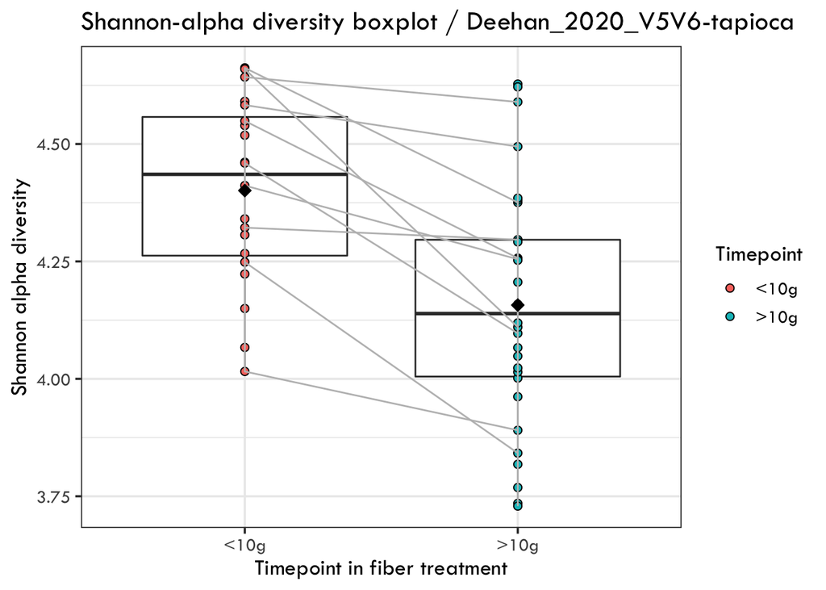

```r
ggplot (merged_alpha, aes(x= factor (fiber_amount2, level= c("<10g",">10g")), y=Shannon)) +
  geom_boxplot() +
  geom_point(shape=21, size=2, (aes(fill = fiber_amount2))) +
  scale_fill_hue(limits = c ("<10g",">10g")) +
  geom_line(aes(group = `subject_id`), color="grey") +
  labs(title = "Shannon-alpha diversity boxplot / Deehan_2020_V5V6-tapioca", x= "Timepoint in fiber treatment", y= "Shannon alpha diversity", fill="Timepoint") +
  theme_bw (base_family = "Tw Cen MT", base_size = 14) +
  stat_summary(fun = mean, geom = "point", shape=23, size=2.5, fill="black")
```

#### Save figure:

```r
ggsave("Figures/shannon_box.ALL.png", width = 7, height = 5)
```

##### Calculate means of both timepoints of Shannon with aggregate program https://r-coder.com/aggregate-r/ :

```r
means.shannon <- aggregate(merged_alpha$Shannon, list(merged_alpha$fiber_amount2), mean)
means.shannon
```

```
#>   Group.1        x
#> 1    <10g 4.400899
#> 2    >10g 4.157071
```

#### Visualization Simpson by all timepoints:

##### Create a boxplot - Simpson:

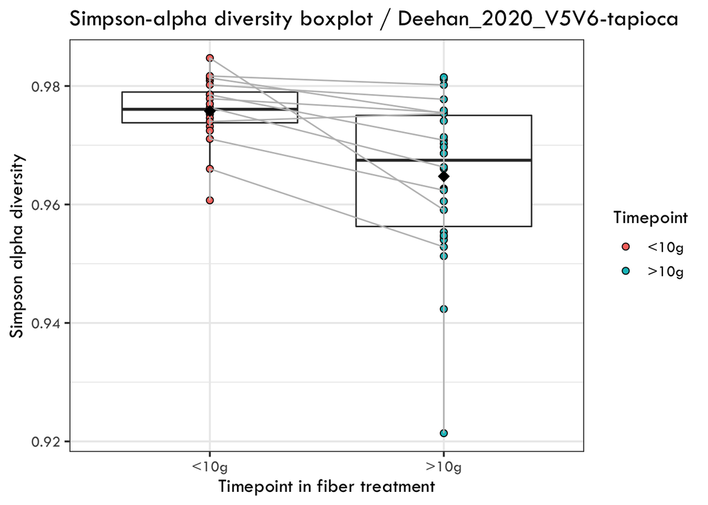

```r
ggplot (merged_alpha, aes(x= factor (fiber_amount2, level= c("<10g",">10g")), y=Simpson)) +
  geom_boxplot() +
  geom_point(shape=21, size=2, (aes(fill = fiber_amount2))) +
  scale_fill_hue(limits = c ("<10g",">10g")) +
  geom_line(aes(group = `subject_id`), color="grey") +
  labs(title = "Simpson-alpha diversity boxplot / Deehan_2020_V5V6-tapioca", x= "Timepoint in fiber treatment", y= "Simpson alpha diversity", fill="Timepoint") +
  theme_bw (base_family = "Tw Cen MT", base_size = 14) +
  stat_summary(fun = mean, geom = "point", shape=23, size=2.5, fill="black")
```

#### Save figure:

```r
ggsave("Figures/simpson_box.ALL.png", width = 7, height = 5)
```

##### Calculate means of both timepoints of Simpson with aggregate program https://r-coder.com/aggregate-r/ :

```r
means.simpson <- aggregate(merged_alpha$Simpson, list(merged_alpha$fiber_amount2), mean)
means.simpson
```

```
#>   Group.1         x
#> 1    <10g 0.9757795
#> 2    >10g 0.9647499
```

#### Visualization Shannon by 2 timepoints only:

##### Subset data for only one timepoint for before and one timepoint for after fiber treatment, so that we can run paired-T-test:

```r
merged_alpha_2 <- merged_alpha [ which(merged_alpha$timepoint_id=='before_1' | merged_alpha$timepoint_id=='after_5'),]
```

#### Save subsetted merged alpha metrics and metadata in a text file:

```r
setwd("/Volumes/Seagate/Meta_analysis/Alpha_Beta_analysis/Deehan_2020_V5V6/tapioca/Output_files")

write.table(x = merged_alpha_2, file = "5.subsetted_tapioca_alpha_metrics_merged_metadata.txt", sep = "\t", row.names = TRUE, col.names = NA)

#Take a look at the first few rows of the merged dataset:
head(merged_alpha_2)
```

```
#>       SampleID Richness  Shannon   Simpson           sampleid  study subject_id
#> 1  SRR10022115      170 4.066896 0.9606999 deehan_SRR10022115 deehan deehan_M41
#> 5  SRR10022119      112 4.001646 0.9686361 deehan_SRR10022119 deehan deehan_M41
#> 18 SRR10022160      283 4.662219 0.9813620 deehan_SRR10022160 deehan deehan_F09
#> 19 SRR10022161      247 4.066349 0.9553548 deehan_SRR10022161 deehan deehan_F09
#> 20 SRR10022167      271 4.461336 0.9752279 deehan_SRR10022167 deehan deehan_F02
#> 21 SRR10022168      301 4.642519 0.9816927 deehan_SRR10022168 deehan deehan_F12
#>    treatment timepoint timepoint_numeric timepoint_id  sample_name fiber_type
#> 1      fiber    before                 1     before_1 deehan_M41_1    tapioca
#> 5      fiber     after                 5      after_5 deehan_M41_5    tapioca
#> 18     fiber    before                 1     before_1 deehan_F09_1    tapioca
#> 19     fiber     after                 5      after_5 deehan_F09_5    tapioca
#> 20     fiber    before                 1     before_1 deehan_F02_1    tapioca
#> 21     fiber    before                 1     before_1 deehan_F12_1    tapioca
#>    fiber_amount time_days number gender age sample-name-original subject_id2
#> 1            0g        0d     24     NA  NA                M41W0         M41
#> 5           50g       28d     28     NA  NA                M41W4         M41
#> 18           0g        0d     69     NA  NA                F09W0         F09
#> 19          50g       28d     70     NA  NA                F09W4         F09
#> 20           0g        0d     76     NA  NA                F02W0         F02
#> 21           0g        0d     77     NA  NA                F12W0         F12
#>      sampleid2 fiber_amount2
#> 1  SRR10022115          <10g
#> 5  SRR10022119          >10g
#> 18 SRR10022160          <10g
#> 19 SRR10022161          >10g
#> 20 SRR10022167          <10g
#> 21 SRR10022168          <10g
```

##### Create a boxplot - Shannon for only before and after fiber treatment:

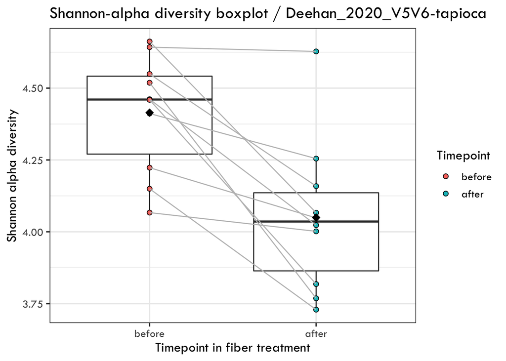

```r
ggplot (merged_alpha_2, aes(x= factor (timepoint, level= c("before","after")), y=Shannon)) +
  geom_boxplot() +
  geom_point(shape=21, size=2, (aes(fill = timepoint))) +
  scale_fill_hue(limits = c ( "before","after")) +
  geom_line(aes(group = `subject_id`), color="grey") +
  labs(title = "Shannon-alpha diversity boxplot / Deehan_2020_V5V6-tapioca", x= "Timepoint in fiber treatment", y= "Shannon alpha diversity", fill="Timepoint") +
  theme_bw (base_family = "Tw Cen MT", base_size = 14) +
  stat_summary(fun = mean, geom = "point", shape=23, size=2.5, fill="black")
```

#### Save figure:

```r
ggsave("Figures/shannon_box.2timepoints.png", width = 7, height = 5)
```

##### Calculate means of both timepoints of Shannon with aggregate program https://r-coder.com/aggregate-r/ :

```r
means.shannon_2 <- aggregate(merged_alpha_2$Shannon, list(merged_alpha_2$timepoint), mean)
means.shannon_2
```

```
#>   Group.1        x
#> 1   after 4.049657
#> 2  before 4.414467
```

##### Create a boxplot - Simpson for only before and after fiber treatment:

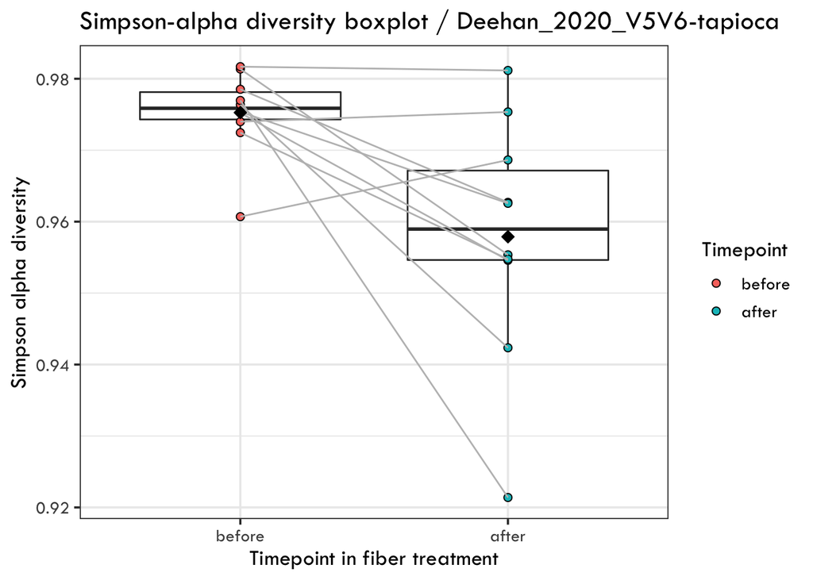

```r
ggplot (merged_alpha_2, aes(x= factor (timepoint, level= c("before","after")), y=Simpson)) +
  geom_boxplot() +
  geom_point(shape=21, size=2, (aes(fill = timepoint))) +
  scale_fill_hue(limits = c ("before","after")) +
  geom_line(aes(group = `subject_id`), color="grey") +
  labs(title = "Simpson-alpha diversity boxplot / Deehan_2020_V5V6-tapioca", x= "Timepoint in fiber treatment", y= "Simpson alpha diversity", fill="Timepoint") +
  theme_bw (base_family = "Tw Cen MT", base_size = 14) +
  stat_summary(fun = mean, geom = "point", shape=23, size=2.5, fill="black")
```

#### Save figure:

```r
ggsave("Figures/simpson_box.2timepoints.png", width = 7, height = 5)
```

#### Calculate means of both timepoints of Simpson with aggregate program https://r-coder.com/aggregate-r/ :

```r
means.simpson_2 <- aggregate(merged_alpha_2$Simpson, list(merged_alpha_2$timepoint), mean)
means.simpson_2
```

```
#>   Group.1         x
#> 1   after 0.9578856
#> 2  before 0.9752673
```

##### Prepare dataframe to correct formatting for statistical testing:

```r
# Delete samples that do not have two timepoints:
pairs.only.all.alpha <- merged_alpha_2 %>%
  filter(duplicated(`subject_id`) | duplicated(`subject_id`, fromLast=TRUE)) %>%
  arrange(`timepoint`,`subject_id`)


#Save file with only before and during subjects, any subjects that did not have all timepoints were deleted:
write.table(x = pairs.only.all.alpha, file = "Output_files/6.tapioca_alpha_metrics_merged_metadata_only_pairs.txt", sep = "\t", row.names = TRUE, col.names = NA)


#Sort the data by timepoint and subject-id:
paired_data_alpha <- pairs.only.all.alpha[order(pairs.only.all.alpha$subject_id, pairs.only.all.alpha$`timepoint`),]

#see sorted data:
head(paired_data_alpha)
```

```
#>       SampleID Richness  Shannon   Simpson           sampleid  study subject_id
#> 1  SRR10022188      226 4.023194 0.9545922 deehan_SRR10022188 deehan deehan_F02
#> 11 SRR10022167      271 4.461336 0.9752279 deehan_SRR10022167 deehan deehan_F02
#> 2  SRR10022161      247 4.066349 0.9553548 deehan_SRR10022161 deehan deehan_F09
#> 12 SRR10022160      283 4.662219 0.9813620 deehan_SRR10022160 deehan deehan_F09
#> 3  SRR10022169      305 4.627627 0.9811612 deehan_SRR10022169 deehan deehan_F12
#> 13 SRR10022168      301 4.642519 0.9816927 deehan_SRR10022168 deehan deehan_F12
#>    treatment timepoint timepoint_numeric timepoint_id  sample_name fiber_type
#> 1      fiber     after                 5      after_5 deehan_F02_5    tapioca
#> 11     fiber    before                 1     before_1 deehan_F02_1    tapioca
#> 2      fiber     after                 5      after_5 deehan_F09_5    tapioca
#> 12     fiber    before                 1     before_1 deehan_F09_1    tapioca
#> 3      fiber     after                 5      after_5 deehan_F12_5    tapioca
#> 13     fiber    before                 1     before_1 deehan_F12_1    tapioca
#>    fiber_amount time_days number gender age sample-name-original subject_id2
#> 1           50g       28d     97     NA  NA                F02W4         F02
#> 11           0g        0d     76     NA  NA                F02W0         F02
#> 2           50g       28d     70     NA  NA                F09W4         F09
#> 12           0g        0d     69     NA  NA                F09W0         F09
#> 3           50g       28d     78     NA  NA                F12W4         F12
#> 13           0g        0d     77     NA  NA                F12W0         F12
#>      sampleid2 fiber_amount2
#> 1  SRR10022188          >10g
#> 11 SRR10022167          <10g
#> 2  SRR10022161          >10g
#> 12 SRR10022160          <10g
#> 3  SRR10022169          >10g
#> 13 SRR10022168          <10g
```

##### Perform summary and statistics to compare alpha diversity metrics between the same subjects before and after fiber intervention:

```r
#Do summary of Shannon alpha metric:
summary(paired_data_alpha$timepoint)
```

```
#>  after before
#>     10     10
```

```r
summary(paired_data_alpha$`subject_id`~timepoint~Shannon)
```

```
#>  Length   Class    Mode
#>       3 formula    call
```

```r
#pairwise t-test Shannon:
pairwise_t_test_shannon<- t.test(Shannon~timepoint,paired=TRUE, data=paired_data_alpha, p.adjust.method = "bonferroni" )
pairwise_t_test_shannon
```

```
#>
#>  Paired t-test
#>
#> data:  Shannon by timepoint
#> t = -4.5492, df = 9, p-value = 0.001387
#> alternative hypothesis: true difference in means is not equal to 0
#> 95 percent confidence interval:
#>  -0.5462163 -0.1834039
#> sample estimates:
#> mean of the differences
#>              -0.3648101
```

```r
#pairwise t-test Simpson:
summary(paired_data_alpha$`subject_id`~timepoint~Simpson)
```

```
#>  Length   Class    Mode
#>       3 formula    call
```

```r
pairwise_t_test_simpson<- t.test(Simpson~timepoint,paired=TRUE, data=paired_data_alpha, p.adjust.method = "bonferroni" )
pairwise_t_test_simpson
```

```
#>
#>  Paired t-test
#>
#> data:  Simpson by timepoint
#> t = -2.9521, df = 9, p-value = 0.01617
#> alternative hypothesis: true difference in means is not equal to 0
#> 95 percent confidence interval:
#>  -0.030701222 -0.004062113
#> sample estimates:
#> mean of the differences
#>             -0.01738167
```

```r
#general linear model:
glm.test.shannon <- glm(Shannon~timepoint, data=paired_data_alpha, family = "gaussian")
glm.test.shannon
```

```
#>
#> Call:  glm(formula = Shannon ~ timepoint, family = "gaussian", data = paired_data_alpha)
#>
#> Coefficients:
#>     (Intercept)  timepointbefore
#>          4.0497           0.3648
#>
#> Degrees of Freedom: 19 Total (i.e. Null);  18 Residual
#> Null Deviance:       1.666
#> Residual Deviance: 1.001     AIC: 2.856
```

```r
#linear mixed model: https://ourcodingclub.github.io/tutorials/mixed-models/
#association between timepoint and the Shannon, we want to know if that association exists after controlling for the variation in subjetc_id.
library(lme4)
lm.test.shannon <- lmer(Shannon~timepoint + (1|`subject_id`), data = paired_data_alpha)
summary(lm.test.shannon)
```

```
#> Linear mixed model fit by REML ['lmerMod']
#> Formula: Shannon ~ timepoint + (1 | subject_id)
#>    Data: paired_data_alpha
#>
#> REML criterion at convergence: 1.9
#>
#> Scaled residuals:
#>     Min      1Q  Median      3Q     Max
#> -1.2841 -0.5680  0.0722  0.4296  1.8901
#>
#> Random effects:
#>  Groups     Name        Variance Std.Dev.
#>  subject_id (Intercept) 0.02344  0.1531
#>  Residual               0.03215  0.1793
#> Number of obs: 20, groups:  subject_id, 10
#>
#> Fixed effects:
#>                 Estimate Std. Error t value
#> (Intercept)      4.04966    0.07456  54.314
#> timepointbefore  0.36481    0.08019   4.549
#>
#> Correlation of Fixed Effects:
#>             (Intr)
#> timepontbfr -0.538
```

##### Looking at these plots and t-tests, there are a number of questions we want to ask:

- Are before fiber samples more/less diverse than after fiber samples?
  - ANSWER: Based on the plots, it seems that alpha diversity decreases
- Does diversity change after treatments?
  - ANSWER: Based on the mean alpha diversity metrics, it seems that after the intervention the diversity decreases
- Is the difference in microbiome richness between before and after fiber treatment statistically significant??
  - ANSWER: YES, based on the paired t-tests for Shannon and Simpson alpha diversity metrics.

## _____________ Beta-Diversity Analysis________

DO NOT use rarefied data here because you can rarefy within the Bray-Curtis calculation:

#### Create your Bray-Curtis dissimilarities to use in NMDS ordination:

- Note: sample = is your rarefaction depth, which we are setting as the lowest reads in our dataset https://rdrr.io/cran/vegan/man/avgdist.html
- Default is Bray-Curtis calculated by vegdist()
- Transform data using square root to minimize influence of most abundant groups.
- avgdist=Averaged Subsampled Dissimilarity Matrices.The function computes the dissimilarity matrix of a dataset multiple times using vegdist while randomly subsampling the dataset each time. All of the subsampled iterations are then averaged (mean or median) to provide a distance matrix that represents the average of multiple subsampling iterations. We use median so as to discount any outlier subsamplings. https://cran.r-project.org/web/packages/vegan/vegan.pdf

```r
set.seed(2022) #reproducible results

bray.dist <- avgdist(SV.table_tapioca,
                     sample = 7157,
                     meanfun = median, transf = sqrt, iterations = 1000)
```

#### Next, run an NMDS, which is a form of ordination and can be used to visualize beta diversity in base R:

```r
set.seed(2022) #reproducible results
NMDS1 <- metaMDS(bray.dist, autotransform = FALSE, k = 2)
```

```
#> *** Solution reached
```

```r
NMDS1
```

```
#>
#> Call:
#> metaMDS(comm = bray.dist, k = 2, autotransform = FALSE)
#>
#> global Multidimensional Scaling using monoMDS
#>
#> Data:     bray.dist
#> Distance: avgdist
#>
#> Dimensions: 2
#> Stress:     0.2234201
#> Stress type 1, weak ties
#> Two convergent solutions found after 20 tries
#> Scaling: centring, PC rotation
#> Species: scores missing
```

##### Store the first two columns as the x and y coordinates, so that they may be plotted:

```r
coordinates <- data.frame(NMDS1$points[,1:2])

#Save Bray-Curtis dissimilarity NMDS cordinates:
  write.table(x = coordinates, file = "Output_files/7.NMDS.coordinates.txt", sep = "\t", row.names = TRUE, col.names = NA)
```

##### Plot the coordinates data from NMDS with base R:

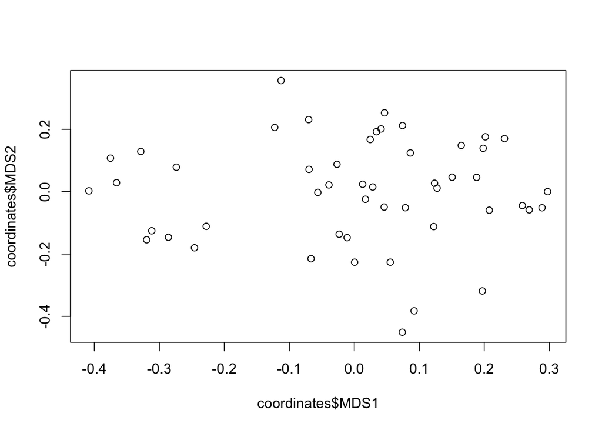

```r
plot(x = coordinates$MDS1, y = coordinates$MDS2)
```

##### To make a more sophisticated plot, merge the stress scores with the metadata file:

```r
nmds_plus_metadata <- merge(coordinates, metadata, by.x = "row.names", by.y = "sample_id_2")

#Save Bray-Curtis dissimilarity NMDS cordinates plus metadata:
  write.table(x = coordinates, file = "Output_files/8.NMDS.coordinates.metadata.txt", sep = "\t", row.names = TRUE, col.names = NA)
```

#### Build NMDS with timepoint as color:

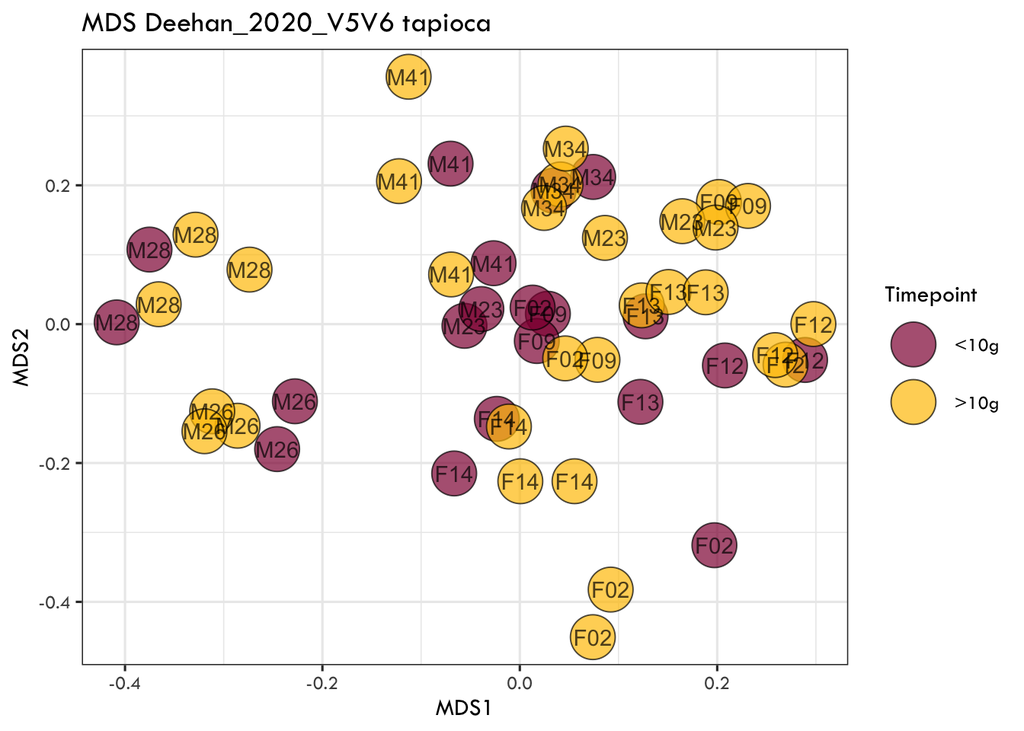

```r
  ggplot(data = nmds_plus_metadata) +
  aes(x = MDS1, y = MDS2, fill = as.factor(`fiber_amount2`)) +
  geom_point(pch = 21, aes(fill = as.factor(`fiber_amount2`)), size = 10, alpha = 0.7) +
  scale_fill_manual(values =c("#900C3F", "#FFC300")) +
  guides(color = F, fill = guide_legend(override.aes = list(shape = 21))) +
  geom_text(label = (nmds_plus_metadata$`subject_id2`), alpha = 0.7) +
labs(title = "MDS Deehan_2020_V5V6 tapioca", x= "MDS1", y= "MDS2", fill="Timepoint") +
  theme_bw (base_family = "Tw Cen MT", base_size = 12)
```

#### Save figure:

```r
ggsave("Figures/NMDS.all.png", width = 7, height = 5)
```

#### To run statistical analyses, make averaged Bray-Curtis dissimilarity matrix:

```r
set.seed(2022) #reproducible results
  bray.dist.matrix <- as.data.frame(as.matrix(avgdist(SV.table_tapioca, sample = 7157, meanfun = median, transf = sqrt, iterations = 1000))) #default is Bray-Curtis calculated by vegdist()
```

#### Save Bray-Curtis dissimilarity matrix in a file:

```r
  write.table(x = bray.dist.matrix, file = "Output_files/9.tapioca_median_bray_curtis_sqrt_q1_forward_rarefied_to_7157.txt", sep = "\t", row.names = TRUE, col.names = NA)
```

#### Confirm variables have been changed to factors in metadata file (if you have not done so already):

```r
class(metadata$`timepoint`)
```

```
#> [1] "factor"
```

```r
class(metadata$`subject_id`)
```

```
#> [1] "factor"
```

```r
class(metadata$`fiber_amount2`)
```

```
#> [1] "factor"
```

#### Example 1,interaction subject X timepoint, by=terms assesses the significance for each term sequentially from first to last:

```r
set.seed(2022) #reproducible results
  PERMANOVA1 <- adonis2(bray.dist.matrix~`subject_id`*`fiber_amount2`, data=metadata, method = "bray", by="terms",permutations = 999)
  PERMANOVA1
```

```
#> Permutation test for adonis under reduced model
#> Terms added sequentially (first to last)
#> Permutation: free
#> Number of permutations: 999
#>
#> adonis2(formula = bray.dist.matrix ~ subject_id * fiber_amount2, data = metadata, permutations = 999, method = "bray", by = "terms")
#>                          Df SumOfSqs      R2       F Pr(>F)
#> subject_id                9   9.5016 0.79073 19.1717  0.001 ***
#> fiber_amount2             1   0.1155 0.00961  2.0975  0.011 *
#> subject_id:fiber_amount2  9   0.7472 0.06218  1.5076  0.003 **
#> Residual                 30   1.6520 0.13748
#> Total                    49  12.0163 1.00000
#> ---
#> Signif. codes:  0 '***' 0.001 '**' 0.01 '*' 0.05 '.' 0.1 ' ' 1
```

```r
  #Save PERMANOVA:
write.table(PERMANOVA1, file = "Output_files/10.PERMANOVA_interaction_term.txt", sep = "\t", row.names = TRUE, col.names = NA)
```

#### Example 2, testing interaction subject X timepoint, ignoring order by=NULL assesses the overall significance of all terms together:

```r
set.seed(2022) #reproducible results
 PERMANOVA2 <- adonis2(bray.dist.matrix~`subject_id`*`fiber_amount2`, data=metadata, method = "bray", by= NULL, permutations = 999)

  PERMANOVA2
```

```
#> Permutation test for adonis under reduced model
#> Permutation: free
#> Number of permutations: 999
#>
#> adonis2(formula = bray.dist.matrix ~ subject_id * fiber_amount2, data = metadata, permutations = 999, method = "bray", by = NULL)
#>          Df SumOfSqs      R2      F Pr(>F)
#> Model    19   10.364 0.86252 9.9058  0.001 ***
#> Residual 30    1.652 0.13748
#> Total    49   12.016 1.00000
#> ---
#> Signif. codes:  0 '***' 0.001 '**' 0.01 '*' 0.05 '.' 0.1 ' ' 1
```

```r
  #Save PERMANOVA:
write.table(PERMANOVA2, file = "Output_files/11.PERMANOVA_interaction_null.txt", sep = "\t", row.names = TRUE, col.names = NA)
```

#### Example 3, not testing interaction subject + timepoint, by=terms assesses the significance for each term sequentially from first to last::

```r
set.seed(2022) #reproducible results
PERMANOVA3 <-  adonis2(bray.dist.matrix~`subject_id`+`fiber_amount2`, data=metadata, method = "bray", by="terms",permutations = 999)

  PERMANOVA3
```

```
#> Permutation test for adonis under reduced model
#> Terms added sequentially (first to last)
#> Permutation: free
#> Number of permutations: 999
#>
#> adonis2(formula = bray.dist.matrix ~ subject_id + fiber_amount2, data = metadata, permutations = 999, method = "bray", by = "terms")
#>               Df SumOfSqs      R2       F Pr(>F)
#> subject_id     9   9.5016 0.79073 17.1616  0.001 ***
#> fiber_amount2  1   0.1155 0.00961  1.8776  0.031 *
#> Residual      39   2.3992 0.19966
#> Total         49  12.0163 1.00000
#> ---
#> Signif. codes:  0 '***' 0.001 '**' 0.01 '*' 0.05 '.' 0.1 ' ' 1
```

```r
  #Save PERMANOVA:
write.table(PERMANOVA3, file = "Output_files/12.PERMANOVA_NOinteraction_term.txt", sep = "\t", row.names = TRUE, col.names = NA)
```

#### Example 4, not testing interaction subject + timepoint, ignoring order by=NULL assesses the overall significance of all terms together:

```r
set.seed(2022) #reproducible results
PERMANOVA4 <-  adonis2(bray.dist.matrix~`subject_id`+`fiber_amount2`, data=metadata, method = "bray", by=NULL,permutations = 999)

  PERMANOVA4
```

```
#> Permutation test for adonis under reduced model
#> Permutation: free
#> Number of permutations: 999
#>
#> adonis2(formula = bray.dist.matrix ~ subject_id + fiber_amount2, data = metadata, permutations = 999, method = "bray", by = NULL)
#>          Df SumOfSqs      R2      F Pr(>F)
#> Model    10   9.6171 0.80034 15.633  0.001 ***
#> Residual 39   2.3992 0.19966
#> Total    49  12.0163 1.00000
#> ---
#> Signif. codes:  0 '***' 0.001 '**' 0.01 '*' 0.05 '.' 0.1 ' ' 1
```

```r
  #Save PERMANOVA:
write.table(PERMANOVA4, file = "Output_files/13.PERMANOVA_NOinteraction_null.txt", sep = "\t", row.names = TRUE, col.names = NA)
```

#### Example 5, testing subject_id by itself:

```r
set.seed(2022) #reproducible results
  adonis2(bray.dist.matrix~`subject_id`, data=metadata, permutations = 999, method = "bray")
```

```
#> Permutation test for adonis under reduced model
#> Terms added sequentially (first to last)
#> Permutation: free
#> Number of permutations: 999
#>
#> adonis2(formula = bray.dist.matrix ~ subject_id, data = metadata, permutations = 999, method = "bray")
#>            Df SumOfSqs      R2      F Pr(>F)
#> subject_id  9   9.5016 0.79073 16.793  0.001 ***
#> Residual   40   2.5147 0.20927
#> Total      49  12.0163 1.00000
#> ---
#> Signif. codes:  0 '***' 0.001 '**' 0.01 '*' 0.05 '.' 0.1 ' ' 1
```

- subject_id = YES significant, explaining 79% of variance
- timepoint (before vs after) = YES significant, explaining 1% of variance (samples were divided by <10gg or >10gg of fiber)
- subject_id and timepoint interaction = YES significant, explaining 6.2% of variance